# Cyclistic bike-share

Linda Perez Jaracuaro

2023-10-18

> 1. Ask

Exploring User Behavior: Annual Members vs. Casual Riders

A Comparative Analysis of Cyclistic Bike Trips to discover how annual members and casuals use Cyclistic bikes differently

> 2. Prepare

Data Source: Ride data

Type of Data: Time-series data

Format: CSV file

Collection Period: August 2022 to July 2023

Description: This data source provides a comprehensive daily history of how different user types utilize our bicycle rental services. It includes detailed information on ride dates, bicycle types used, and the geographical coordinates of both the starting and ending points of each ride. The data was meticulously recorded and collected from our internal system, which serves as a valuable resource for understanding user preferences.

```r
# Include libraries
library(DescTools)
library("geosphere")
library(hydroTSM)
library(lubridate)
library(scales)
library(tidyverse)

# Unify in one data frame called df, data cvs available from one year
files <- list.files(path = "./Data files",
                    pattern = ".*-divvy-tripdata\\.csv$",
                    full.names = TRUE)
df_list <- lapply(files, read_csv)
df <- bind_rows(df_list)

#Remove unnecessary variables
rm(files, df_list)
```

> 3. Process

**Integrity data check**

```r
#Create a data frame that contains all observations with one or more missing values
missing_values <- df %>%
  filter_all(any_vars(is.na(.)))

#Calculate the number of missing values in each column of missing_values
missing_values_count <- colSums(is.na(missing_values))

#Identify columns with missing values
columns_with_missing_values <- names(missing_values_count[missing_values_count > 0])

#Find percentage of missing data from df
missing_percent <- nrow(missing_values) / nrow(df)
```

After an integrity data check it was found that a total of 2.4% observations contains missing values for start_station_id, start_station_name, end_station_id, end_station_name, end_lat and end_lng

Each variable will undergo an individualized analysis to unveil its specific relationship with ‘member_casual.’ during Analysis phase. Consequently, this analysis will guide the decision of whether to include or exclude data with missing values for that variable. Our overarching goal is to comprehensively analyze all available data without compromising the integrity of the research.

**Add variables for further analysis**

- day_of_week

```r
#Calculate day_of_week
df <- df %>%
  mutate(
    day_of_week = wday(started_at)
  )
```

- distance

```r
#Create distance variable from latitude and longitude values distance is measured by meters distance will not consider 0 values for computing
df <- df %>%
  mutate(distance = distVincentySphere(
    cbind(start_lng, start_lat),
    cbind(end_lng, end_lat))
  ) %>%
  filter(distance > 0)
```

- month

```r
# Calculate month
df <- df %>%
  mutate(month = month(started_at,  label = TRUE, abbr = TRUE))
```

- ride_length (time)

```r
# Calculate time used and pase it to numeric for computing and store it as minutes
df <- df %>%
  mutate(ride_length = as.numeric(ended_at - started_at) /60)
```

```r
# Look to the data
min(df$ride_length)
```

```
## [1] -10353.35
```

```r
max(df$ride_length)
```

```
## [1] 12136.3
```

```r
# Remove rides shorter than one minute
df <- df %>%
  filter(ride_length >= 1 )
```

- seasons

```r
#Calculate season
df <- df %>%
  mutate(season = time2season(started_at, out.fmt = "seasons"))
```

- time_of_day

```r
#create breaks
day_timing_breaks <- hour(hm("00:00", "6:00", "12:00", "18:00", "23:59"))
#labels for the breaks
day_timing_lst <- c("Night", "Morning", "Afternoon", "Evening")
# Add time_of_day variable
df$time_of_day <- cut(x = hour(df$started_at),
                      breaks = day_timing_breaks,
                      labels = day_timing_lst,
                      include.lowest=TRUE)
```

> 4. Analyze

Generate comprehensive variable summaries to gain deeper insights into their relationships with the members in your data analysis.

#### *day_of_week*

Summary of trips by day of week

```r
weekdays_lst <- c("Mon", "Tues", "Wed", "Thurs", "Fri", "Sat", "Sun")
sum_day_of_week <- df %>%
  group_by(member_casual, day_of_week) %>%
  summarise(num_trips = n()) %>%
  mutate( day_of_week = weekdays_lst[day_of_week],
          total = sum(num_trips),
          perc = round( ((num_trips / total) * 100), 2 )) %>%
  select(member_casual, day_of_week, perc, num_trips)
# Add day_of_week variable using a factor
sum_day_of_week$day_of_week <- factor(sum_day_of_week$day_of_week, levels = weekdays_lst)
```

#### *distance*

Summary of trips by distance measured in meters

```r
sum_distance <- df %>%
  filter(distance > 0) %>%
  group_by(member_casual) %>%
  summarise(mean = mean(distance, na.rm = TRUE),
            median = median(distance, na.rm = TRUE),
            mode = Mode(distance, na.rm = TRUE))
```

#### *member_casual*

Compute cyclist type percentage

```r
sum_member <- df %>%
  group_by(member_casual) %>%
  summarise(count = n()) %>%
  mutate(perc = count / sum(count))
```

#### *month*

Summary of trips by month

```r
sum_months <- df %>%
  group_by(member_casual, month) %>%
  summarise(num_trips = n()) %>%
  mutate( total = sum(num_trips),
          perc = round( ((num_trips / total) * 100), 2 )) %>%
  select(member_casual, month, perc, num_trips)
```

#### *ride_length (time)*

Summary of trips by ride length, in other words ride time

```r
sum_time <- df %>%
  group_by(member_casual) %>%
  summarise(mean = mean(ride_length, na.rm = TRUE),
            median = median(ride_length, na.rm = TRUE),
            mode = Mode(ride_length, na.rm = TRUE))
```

#### *rideable_bike*

Summary of bike types used by each type of member

```r
sum_bike <- df %>%
  group_by(member_casual, rideable_type) %>%
  summarise(count = n()) %>%
  mutate(perc = count / sum(count),
         rideable_type = sub("_.*", "", rideable_type))
```

#### *seasons*

Summary of trips by season

```r
#Season list, it will be used for factor
season_lst <- c('spring', 'summer', 'autumm', 'winter')
sum_season <- df %>%
  group_by(member_casual, season) %>%
  summarise(num_trips = n()) %>%
  mutate(total = sum(num_trips),
         perc = round( ((num_trips / total) * 100), 2 )) %>%
  select(member_casual, season, num_trips, perc)
# Add season using a factor
sum_season$season <- factor(sum_season$season, levels = season_lst)
```

#### *time_of_day*

Summary of time of the day

```r
sum_day_timing <- df %>%
  group_by(member_casual, time_of_day) %>%
  summarise(num_trips = n()) %>%
  mutate( total = sum(num_trips),
          perc = round( ((num_trips / total) * 100), 2 )) %>%
  select(member_casual, time_of_day, perc, num_trips)
```

#### *top_stations*

Rank of most common start station for each type of member

*For start stations

```r
# For casual users
top_start_station_casual <- df %>%
  filter(!is.na(start_station_id) & member_casual == 'casual') %>%
  mutate(id = start_station_id,
         name = start_station_name) %>%
  group_by(id, name) %>%
  summarise(member_casual = "casual",
            type = "start",
            count = n())
top_start_station_casual$rank <- min_rank( desc(top_start_station_casual$count) )
top_start_station_casual <- top_start_station_casual %>%
  filter(rank <= 10) %>%
  arrange(rank)

# For annual member
top_start_station_member <- df %>%
  filter(!is.na(start_station_id) & member_casual == 'member') %>%
  mutate(id = start_station_id,
         name = start_station_name) %>%
  group_by(id, name) %>%
  summarise(member_casual = "member",
            type = "start",
            count = n())
top_start_station_member$rank <- min_rank( desc(top_start_station_member$count) )
top_start_station_member <- top_start_station_member %>%
  filter(rank <= 10) %>%
  arrange(rank)
```

- For end stations

```r
# For casual users
top_end_station_casual <- df %>%
  filter(!is.na(end_station_id) & member_casual == 'casual') %>%
  mutate(id = end_station_id,
         name = end_station_name) %>%
  group_by(id, name) %>%
  summarise(member_casual = "casual",
            type = "end",
            count = n())
top_end_station_casual$rank <- min_rank( desc(top_end_station_casual$count) )
top_end_station_casual <- top_end_station_casual %>%
  filter(rank <= 10) %>%
  arrange(rank)

# For annual members
top_end_station_member <- df %>%
  filter(!is.na(end_station_id) & member_casual == 'member') %>%
  mutate(id = end_station_id,
         name = end_station_name) %>%
  group_by(id, name) %>%
  summarise(member_casual = "member",
            type = "end",
            count = n())
top_end_station_member$rank <- min_rank( desc(top_end_station_member$count) )
top_end_station_member <- top_end_station_member %>%
  filter(rank <= 10) %>%
  arrange(rank)

# Summary top stations both start and end
sum_top_stations <-rbind(top_start_station_casual,
                         top_start_station_member,
                         top_end_station_casual,
                         top_end_station_member)

# Remove variables
rm(top_start_station_casual,
    top_start_station_member,
    top_end_station_casual,
    top_end_station_member)
```

#### *stations_location*

```r
top_station_id <- sum_top_stations$id %>%
  unique()

start_stations_location <- df %>%
  mutate(id = start_station_id,
         name = start_station_name) %>%
  group_by(id, name) %>%
  summarise(latitude = mean(start_lat),
            longitude = mean(start_lng))

end_stations_location <- df %>%
  mutate(id = end_station_id,
         name = end_station_name) %>%
  group_by(id, name) %>%
  summarise(latitude = mean(end_lat),
            longitude = mean(end_lng))

stations_location <- rbind(start_stations_location,
                           end_stations_location) %>%
  group_by(id, name) %>%
  filter(id %in% top_station_id) %>%
  summarise(latitude = mean(latitude),
            longitude = mean(longitude))

# Merge both stations df
sum_top_stations <- sum_top_stations %>%
  left_join(stations_location) %>%
  mutate(city = "Chicago")

top_station_member <- sum_top_stations %>%
  filter(id %in% top_station_id & member_casual == "member") %>%
  select(-type) %>%
  group_by(id)
top_station_casual <- sum_top_stations %>%
  filter(id %in% top_station_id & member_casual == "casual") %>%
  select(-type) %>%
  group_by(id)

# Write csv file for each type of user
write.csv(top_station_member, "Top stations - member.csv", row.names=TRUE)
write.csv(top_station_casual, "Top stations - casual.csv", row.names=TRUE)

# Export sum_top_stations to csv format for latter analysis in Tableau
write.csv(sum_top_stations, "Top stations.csv", row.names=TRUE)

rm(start_stations_location, end_stations_location, stations_location)
```

> 5. Share

```r
#Declare colors for cyclist type
colors_lst <- c("#3f94a3", "gray")

# Define two colors you to interpolate between and create a palette for other groups, like months, weekday, time_of_day
color_start <- "#d6eaee"
color_end <- "#3f94a3"

# Open a pdf
pdf("Media files\\Cyclistic_models.pdf")
```

#### *day_of_week*

Option 1: Stacked vertical bar chart by trips percentage

[figure not shown]

```r
ggplot() +
  geom_col(data = sum_day_of_week,
           mapping = aes(x = member_casual,
                         y = perc,
                         fill = day_of_week),
           show.legend = TRUE,
           color = "white") +
  scale_fill_manual(values = c( "gray", "gray","gray", "gray","gray", "#3f94a3","#3f94a3")) +
  labs(title = "Weekday breakdown",
       subtitle = "Past 12 months",
       y = "Rides  (%)",
       x = "",
       fill = "") +
  theme_classic()
```

Option 2: Line chart by trips total

[figure not shown]

```r
ggplot(data = sum_day_of_week,
       mapping = aes(x = day_of_week,
                     y = num_trips,
                     group = member_casual,
                     color = member_casual)) +
  geom_line(show.legend = TRUE) +
  geom_point() +
  scale_color_manual(values = colors_lst) +
  scale_y_continuous(labels = unit_format(unit = "", scale = 1e-3)) +
  labs(title = "Weekday breakdown",
       subtitle = "Past 12 months",
       y = "Rides (thousands)",
       x = "",
       color = "Cyclist  type") +
  theme_classic()
```

Option 3: Horizontal bar graph by trips total

[figure not shown]

```r
ggplot(data = sum_day_of_week,
       mapping = aes(x = day_of_week,
                     y = num_trips,
                     group = member_casual,
                     fill = member_casual)) +
  geom_col(position = "dodge",
           width = 0.7,
           show.legend = TRUE) +
  coord_flip()+
  scale_fill_manual(values = colors_lst) +
  scale_y_continuous(labels = unit_format(unit = "", scale = 1e-3)) +
  labs(title = "Weekday breakdown",
       subtitle = "Past 12 months",
       y = "Rides (thousands)",
       x = "",
       fill = "Cyclist  type") +
  theme_classic()
```

#### *distance*

Mean distance by each type of member

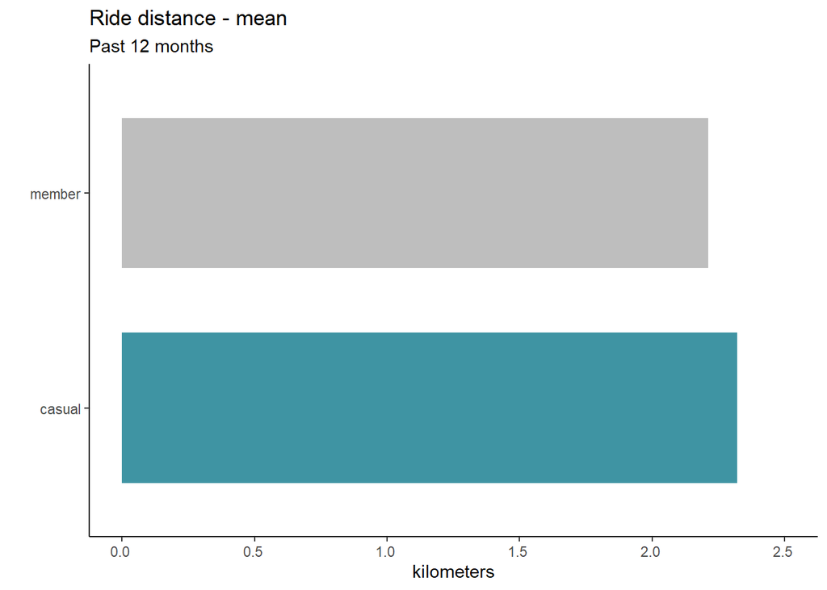

```r
ggplot(data = sum_distance) +
  geom_col(
    mapping = aes(x = member_casual,
                  y = mean,
                  fill = member_casual),
    show.legend = FALSE,
    width = 0.7) +
  coord_flip(ylim = c(0, 2500)) +
  scale_fill_manual(values = colors_lst) +
  scale_y_continuous(labels = unit_format(unit = "", scale = 1e-3)) +
  labs(title = "Ride distance - mean",
       subtitle = "Past 12 months",
       y = "kilometers",
       x = "",
       fill = "Cyclist  type") +
  theme_classic()
```

Median distance by each type of member

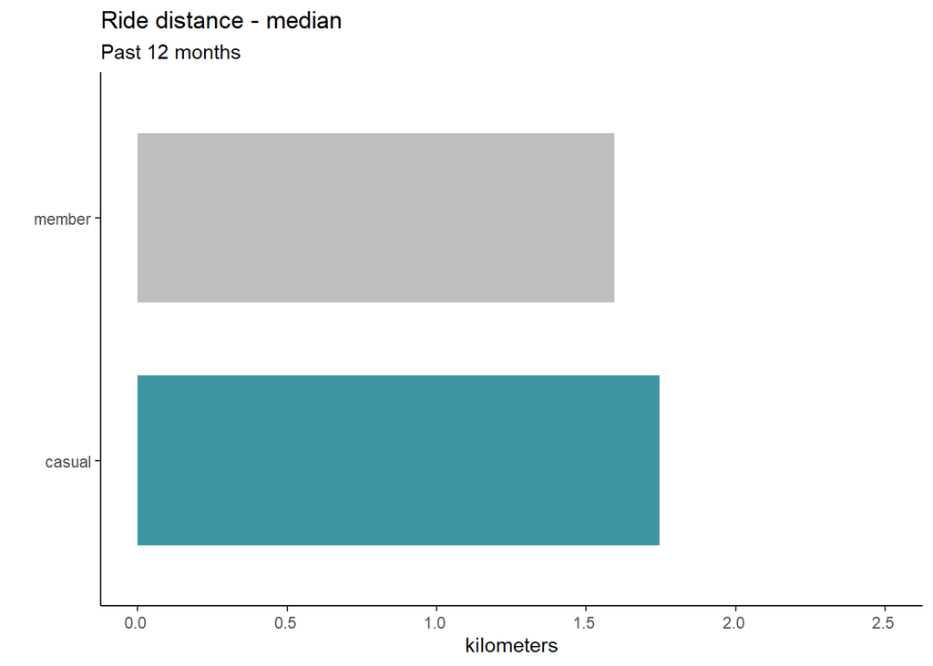

```r
ggplot(data = sum_distance) +
  geom_col(
    mapping = aes(x = member_casual,
                  y = median,
                  fill = member_casual),
    show.legend = FALSE,
    width = 0.7) +
  coord_flip(ylim = c(0, 2500)) +
  scale_fill_manual(values = colors_lst) +
  scale_y_continuous(labels = unit_format(unit = "", scale = 1e-3)) +
  labs(title = "Ride distance - median",
       subtitle = "Past 12 months",
       y = "kilometers",
       x = "",
       fill = "Cyclist  type") +
  theme_classic()
```

Mode distance by each type of member

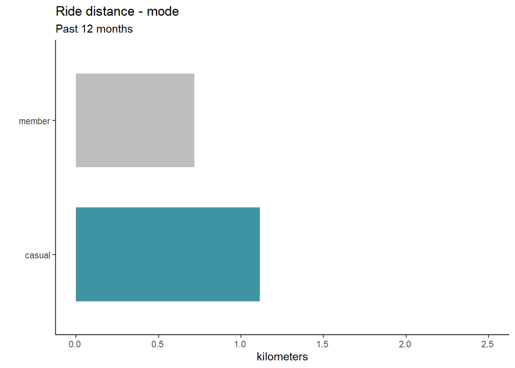

```r
ggplot(data = sum_distance) +
  geom_col(
    mapping = aes(x = member_casual,
                  y = mode,
                  fill = member_casual),
    show.legend = FALSE,
    width = 0.7) +
  coord_flip(ylim = c(0, 2500)) +
  scale_fill_manual(values = colors_lst) +
  scale_y_continuous(labels = unit_format(unit = "", scale = 1e-3)) +
  labs(title = "Ride distance - mode",
       subtitle = "Past 12 months",
       y = "kilometers",
       x = "",
       fill = "Cyclist  type") +
  theme_classic()
```

#### *member_casual*

Plot member type difference

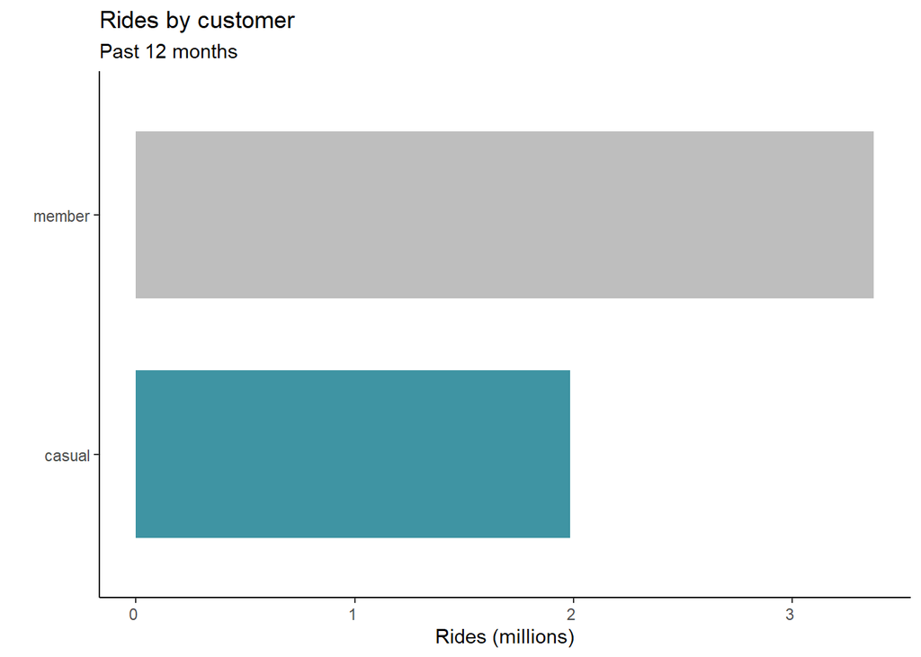

```r
ggplot() +
  geom_col(data = sum_member,
           mapping = aes(x = member_casual,
                         y = count,
                         fill = member_casual),
           show.legend = FALSE,
           width = 0.7) +
  scale_y_continuous(labels = unit_format(unit = "", scale = 1e-6)) +
  scale_fill_manual(values = colors_lst) +
  coord_flip() +
  labs(title = "Rides by customer",
       subtitle = "Past 12 months",
       y = "Rides (millions)",
       x = "") +
  theme_classic()
```

#### *month*

```r
#Define color palette to use
months_palette <- colorRampPalette(c(color_start, color_end))(12)
```

Option 1: Vertical stacked bar chart by trips percentage

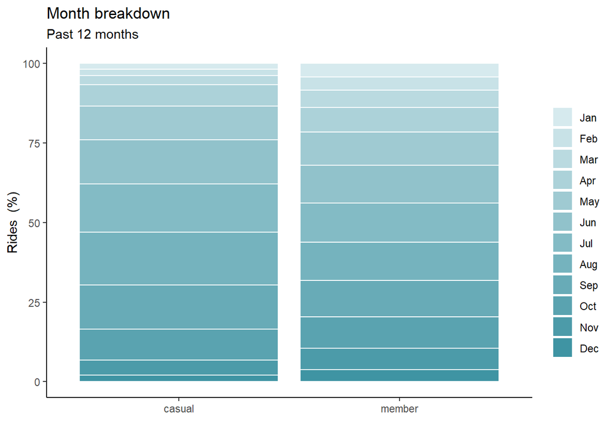

```r
ggplot() +
  geom_col(data = sum_months,
           mapping = aes(x = member_casual,
                         y = perc,
                         fill = month),
           show.legend = TRUE,
           color = "white") +
  scale_fill_manual(values = months_palette) +
  labs(title = "Month breakdown",
       subtitle = "Past 12 months",
       y = "Rides  (%)",
       x = "",
       fill =  "") +
  theme_classic()
```

Option 2: Line graph by trips total

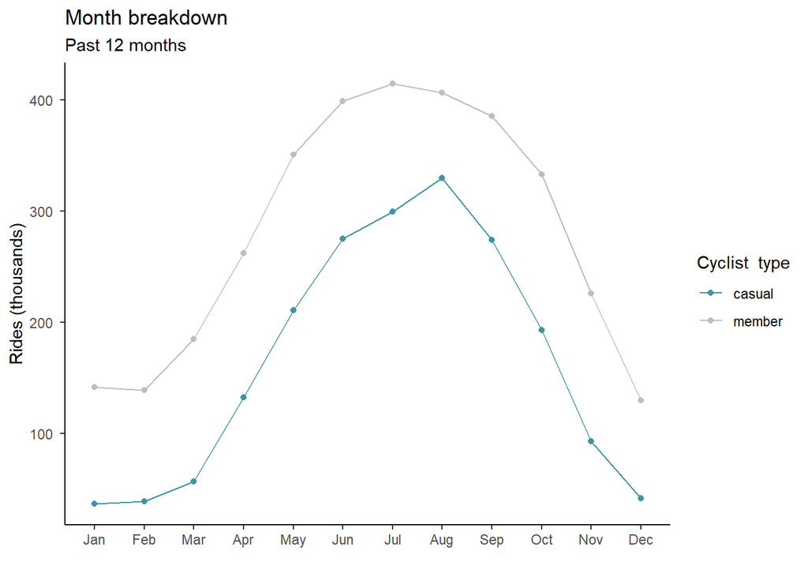

```r
ggplot(data = sum_months,
       mapping = aes(x = month,
                     y = num_trips,
                     group = member_casual,
                     color = member_casual)) +
  geom_line(show.legend = TRUE) +
  geom_point() +
  scale_color_manual(values = colors_lst) +
  scale_y_continuous(labels = unit_format(unit = "", scale = 1e-3)) +
  labs(title = "Month breakdown",
       subtitle = "Past 12 months",
       y = "Rides (thousands)",
       x = "",
       color = "Cyclist  type") +
  theme_classic()
```

Option 3: Horizontal bar chart by trips total

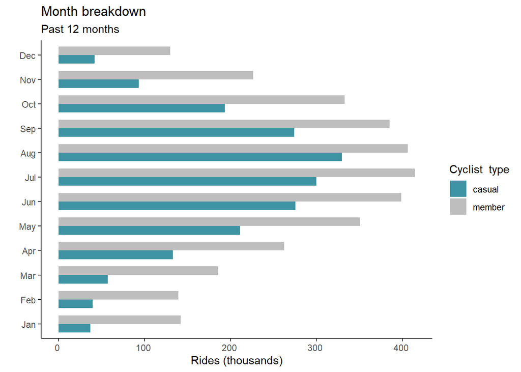

```r
ggplot(data = sum_months,
       mapping = aes(x = month,
                     y = num_trips,
                     fill = member_casual
                     )) +
  geom_col(  width = 0.7,
             position = "dodge",
             show.legend = TRUE) +
  scale_fill_manual(values = colors_lst) +
  scale_y_continuous(labels = unit_format(unit = "", scale = 1e-3)) +
  coord_flip() +
  labs(title = "Month breakdown",
       subtitle = "Past 12 months",
       y = "Rides (thousands)",
       x = "",
       fill = "Cyclist  type") +
  theme_classic()
```

#### *ride_length (time)*

Plot ride length for each type of user (time)

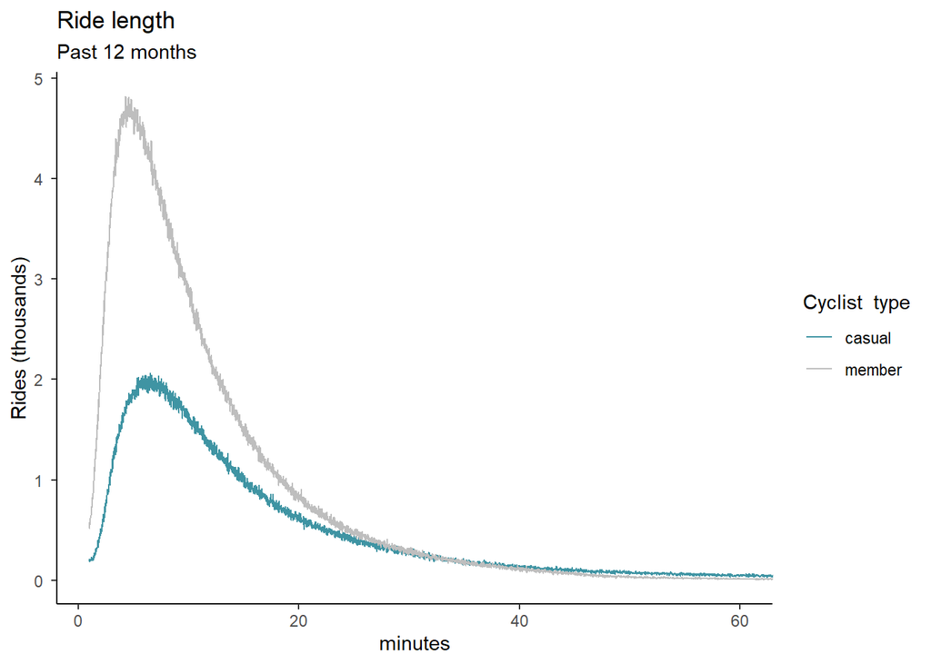

```r
ggplot() +
  geom_line(
    data = df,
    mapping = aes(x = ride_length,
                  group = member_casual,
                  color = member_casual),
    stat = "count",
    show.legend = TRUE) +
  scale_color_manual(values = colors_lst)+
  scale_y_continuous(labels = unit_format(unit = "", scale = 1e-3)) +
  coord_cartesian(xlim = c(1, 60)) +
  labs(title = "Ride length",
       subtitle = "Past 12 months",
       y = "Rides (thousands)",
       x = "minutes",
       color = "Cyclist  type") +
  theme_classic()
```

Mean time by each type of member

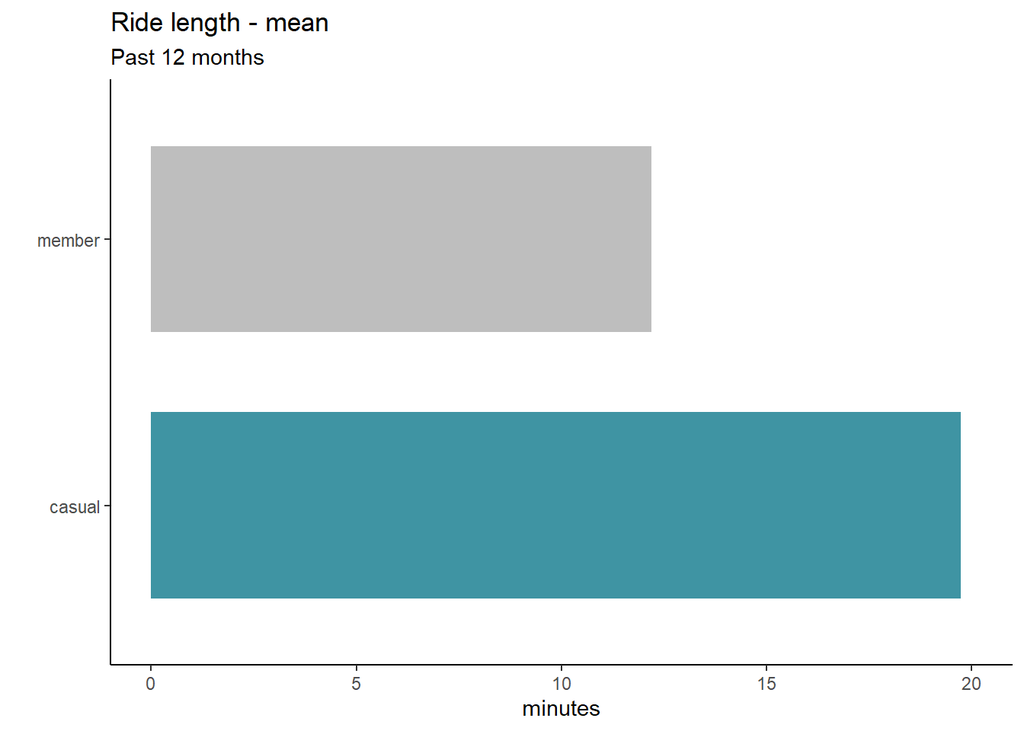

```r
ggplot(data = sum_time) +
  geom_col(
    mapping = aes(x = member_casual,
                  y = mean,
                  fill = member_casual),
    show.legend = FALSE,
    width = 0.7) +
  coord_flip(ylim = c(0, 20)) +
  scale_fill_manual(values = colors_lst) +
  labs(title = "Ride length - mean",
       subtitle = "Past 12 months",
       y = "minutes",
       x = "",
       fill = "Cyclist  type") +
  theme_classic()
```

Median time by each type of member

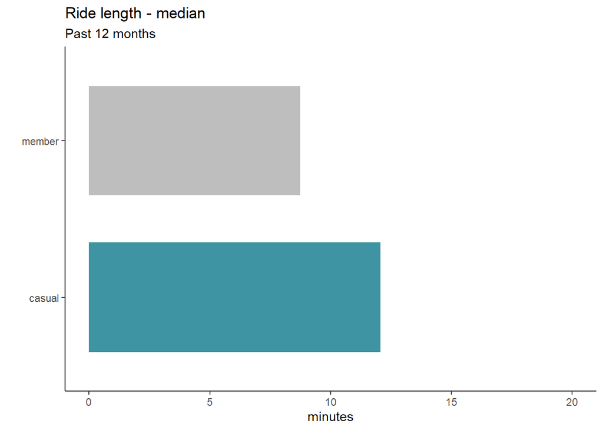

```r
ggplot(data = sum_time) +
  geom_col(
    mapping = aes(x = member_casual,
                  y = median,
                  fill = member_casual),
    show.legend = FALSE,
    width = 0.7) +
  coord_flip(ylim = c(0, 20)) +
  scale_fill_manual(values = colors_lst) +
  labs(title = "Ride length - median",
       subtitle = "Past 12 months",
       y = "minutes",
       x = "",
       fill = "Cyclist  type") +
  theme_classic()
```

Common ride length time by each type of member

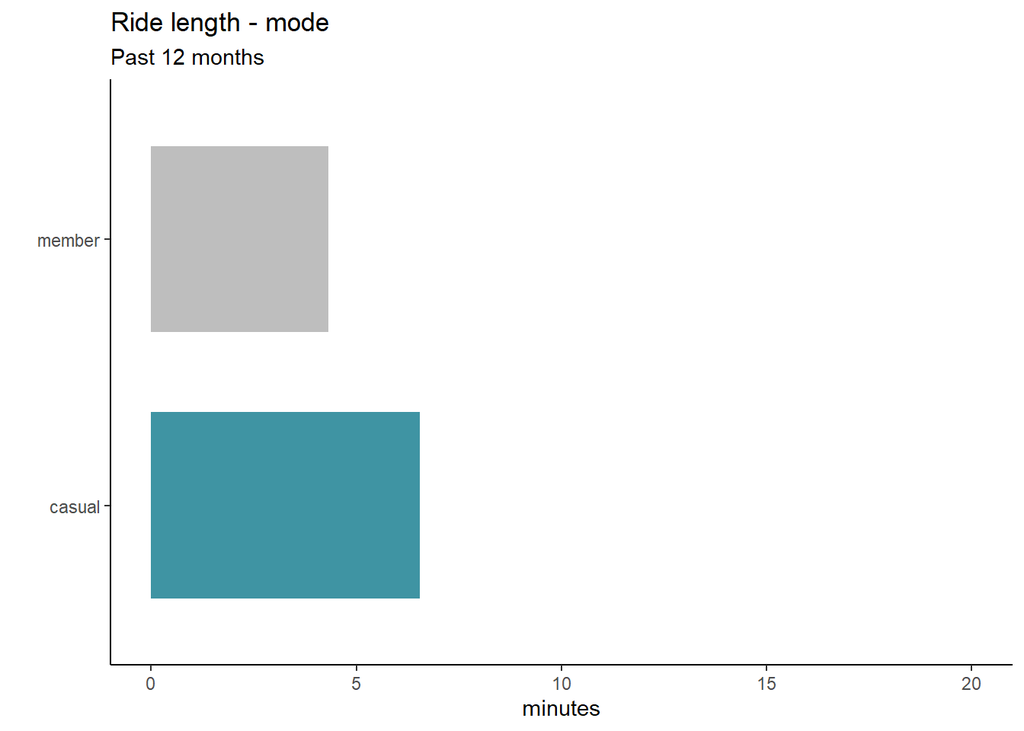

```r
ggplot(data = sum_time) +
  geom_col(
    mapping = aes(x = member_casual,
                  y = mode,
                  fill = member_casual),
    show.legend = FALSE,
    width = 0.7) +
  coord_flip(ylim = c(0, 20)) +
  scale_fill_manual(values = colors_lst) +
  labs(title = "Ride length - mode",
       subtitle = "Past 12 months",
       y = "minutes",
       x = "",
       fill = "Cyclist  type") +
  theme_classic()
```

#### *rideable_bike*

```r
#Define color palette to use
rideable_bike_palette <- colorRampPalette(c(color_start, color_end))(3)
```

Plot rideable_bike type for each type of member

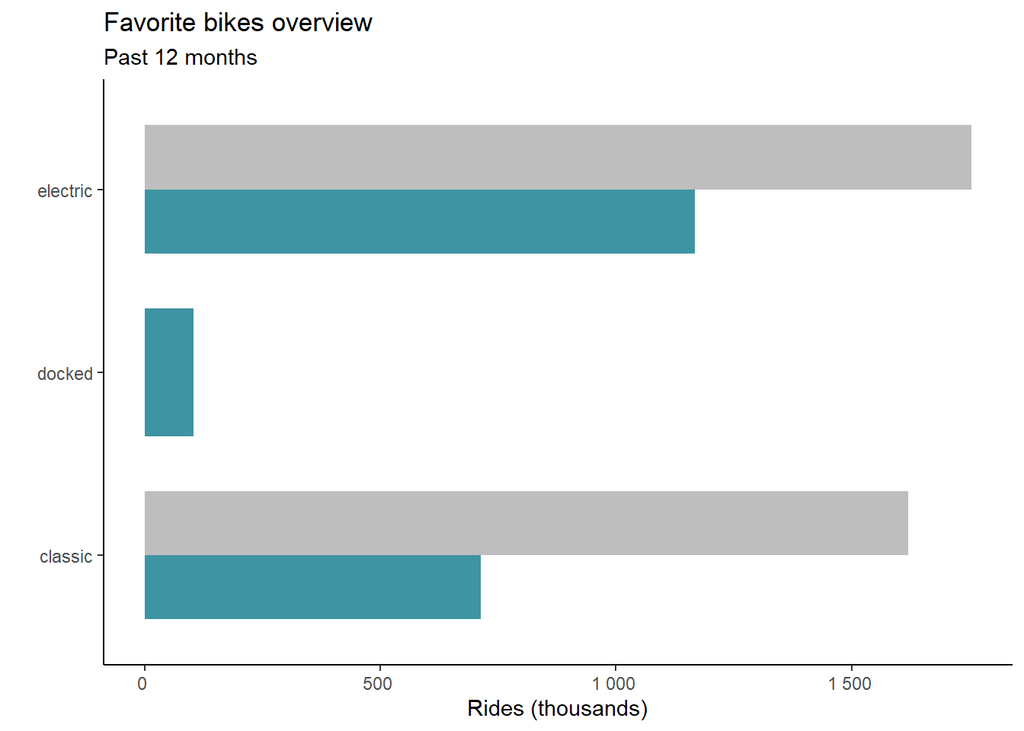

```r
# Option 1: Horizontal bar chart by trips total
ggplot() +
  geom_col(data = sum_bike,
           mapping = aes(x = rideable_type,
                         y = count,
                         fill = member_casual),
           position = "dodge",
           show.legend = FALSE,
           width = 0.7) +
  scale_y_continuous(labels = unit_format(unit = "", scale = 1e-3)) +
  scale_fill_manual(values = colors_lst) +
  coord_flip() +
  labs(title = "Favorite bikes overview",
       subtitle = "Past 12 months",
       y = "Rides (thousands)",
       x = "") +
  theme_classic()
```

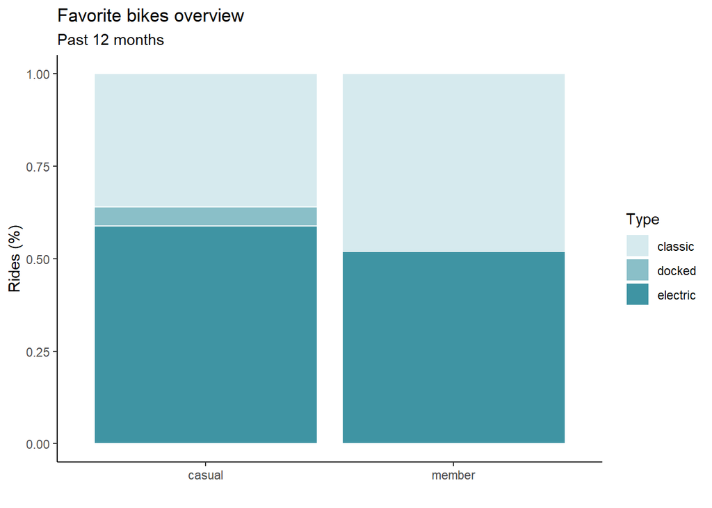

```r
# Option 2: Vertical stacked bar chart by trips total
ggplot() +
  geom_col(data = sum_bike,
           mapping = aes(x = member_casual,
                         y = perc,
                         fill = rideable_type),
           color = "white",
           show.legend = TRUE) +
  scale_fill_manual(values = rideable_bike_palette)+
  labs(title = "Favorite bikes overview",
       subtitle = "Past 12 months",
       y = "Rides (%)",
       x = "",
       fill = "Type")+
  theme_classic()
```

#### *seasons*

```r
#Define color palette to use
seasons_palette <- colorRampPalette(c(color_start, color_end))(4)
```

Option 1: Line chart by trips total

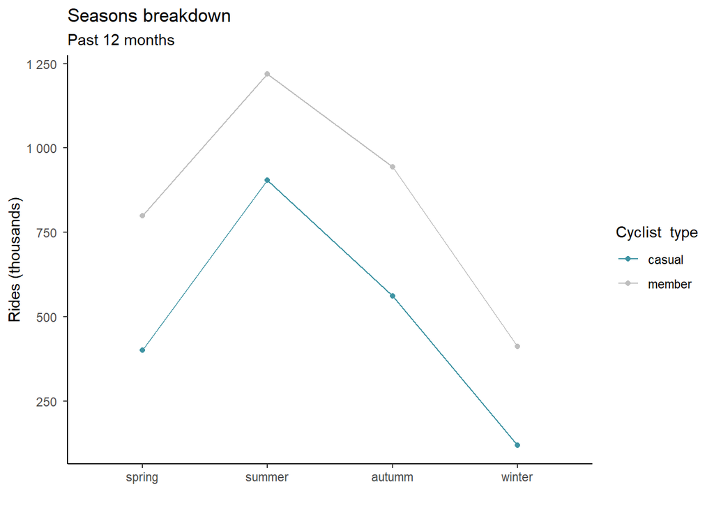

```r
ggplot(data = sum_season,
       mapping = aes(x = season,
                     y = num_trips,
                     group = member_casual,
                     color = member_casual),
       show.legend = TRUE) +
  geom_line() +
  geom_point() +
  scale_color_manual(values = colors_lst) +
  scale_y_continuous(labels = unit_format(unit = "", scale = 1e-3)) +
  labs(title = "Seasons breakdown",
       subtitle = "Past 12 months",
       y = "Rides (thousands)",
       x = "",
       color = "Cyclist  type")+
  theme_classic()
```

Option 2: Horizontal bar chart by trips total

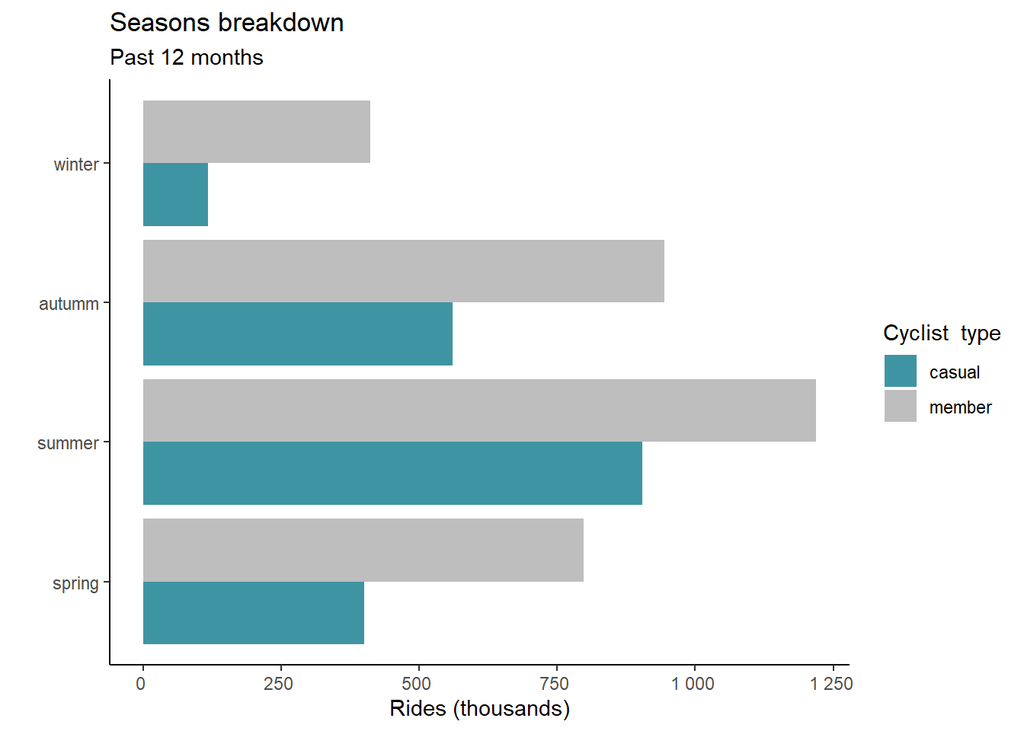

```r
ggplot(data = sum_season,
       mapping = aes(x = season,
                     y = num_trips,
                     group = member_casual,
                     fill = member_casual),
       show.legend = TRUE) +
  geom_col(position = "dodge") +
  coord_flip() +
  scale_fill_manual(values = colors_lst) +
  scale_y_continuous(labels = unit_format(unit = "", scale = 1e-3)) +
  labs(title = "Seasons breakdown",
       subtitle = "Past 12 months",
       y = "Rides (thousands)",
       x = "",
       fill = "Cyclist  type")+
  theme_classic()
```

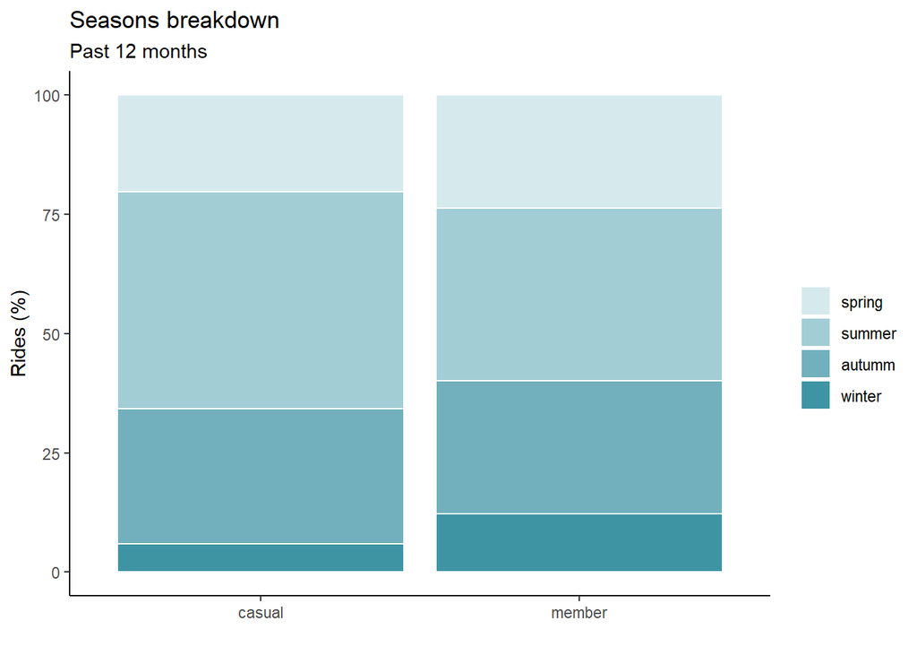

```r
ggplot() +
  geom_col(data = sum_season,
            mapping = aes(x = member_casual,
                          y = perc,
                          fill = season),
           color = "white",
           show.legend = TRUE) +
  scale_fill_manual(values = seasons_palette) +
  labs(title = "Seasons breakdown",
       subtitle = "Past 12 months",
       y = "Rides (%)",
       x = "",
       fill =  "")+
  theme_classic()
```

#### *time_of_day*

```r
#Define color palette to use
time_of_day_palette <- colorRampPalette(c(color_start, color_end))(4)
```

Option 1: Vertical stacked bar graph by trips percentage

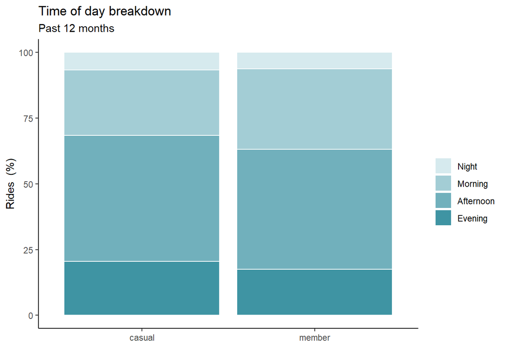

```r
ggplot() +
  geom_col(data = sum_day_timing,
           mapping = aes(x = member_casual,
                         y = perc,
                         fill = time_of_day),
           show.legend = TRUE,
           color = "white") +
  scale_fill_manual(values = time_of_day_palette)+
  labs(title = "Time of day breakdown",
       subtitle = "Past 12 months",
       y = "Rides  (%)",
       x = "",
       fill = "") +
  theme_classic()
```

Option 2: Line graph by trips total

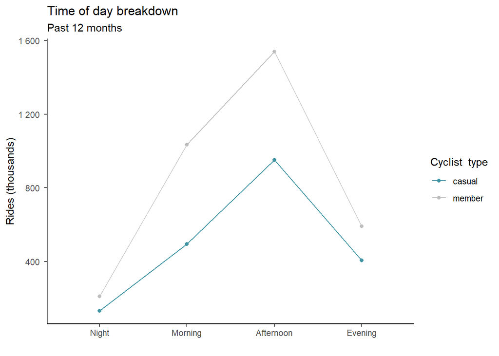

```r
ggplot(data = sum_day_timing,
       mapping = aes(x = time_of_day,
                     y = num_trips,
                     group = member_casual,
                     color = member_casual)) +
  geom_line(show.legend = TRUE) +
  geom_point() +
  scale_color_manual(values = colors_lst) +
  scale_y_continuous(labels = unit_format(unit = "", scale = 1e-3)) +
  labs(title = "Time of day breakdown",
       subtitle = "Past 12 months",
       y = "Rides (thousands)",
       x = "",
       color = "Cyclist  type") +
  theme_classic()
```

Option 3: Horizontal bar graph by trips total

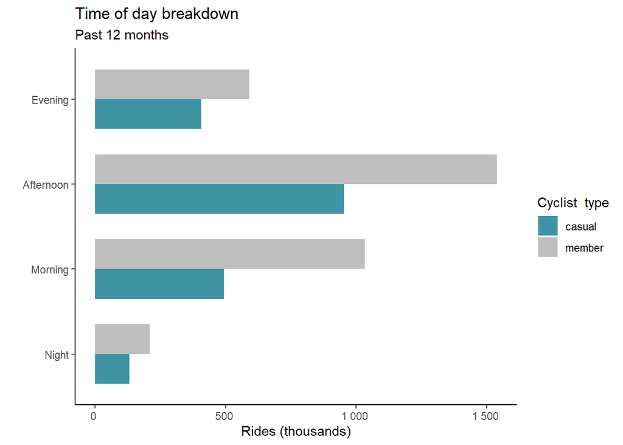

```r
ggplot(data = sum_day_timing,
       mapping = aes(x = time_of_day,
                     y = num_trips,
                     fill = member_casual
       )) +
  geom_col(  width = 0.7,
             position = "dodge",
             show.legend = TRUE) +
  scale_fill_manual(values = colors_lst) +
  scale_y_continuous(labels = unit_format(unit = "", scale = 1e-3)) +
  coord_flip() +
  labs(title = "Time of day breakdown",
       subtitle = "Past 12 months",
       y = "Rides (thousands)",
       x = "",
       fill = "Cyclist  type") +
  theme_classic()
```

```r
# Close the pdf file
dev.off()
```